###### IODS - Introduction to Open Data Science - 2017

# Week 3:

## Logistic regression

Data wrangling exercise can be found in file “data/create_alc.R”.

The dataset concerns correlation between alcohol usage and social, gender and study time attributes for each student.

```r
alc <- read.table("http://s3.amazonaws.com/assets.datacamp.com/production/course_2218/datasets/alc.txt", header=TRUE, sep=",")
colnames(alc)
```

```
##  [1] "school"     "sex"        "age"        "address"    "famsize"
##  [6] "Pstatus"    "Medu"       "Fedu"       "Mjob"       "Fjob"
## [11] "reason"     "nursery"    "internet"   "guardian"   "traveltime"
## [16] "studytime"  "failures"   "schoolsup"  "famsup"     "paid"
## [21] "activities" "higher"     "romantic"   "famrel"     "freetime"
## [26] "goout"      "Dalc"       "Walc"       "health"     "absences"
## [31] "G1"         "G2"         "G3"         "alc_use"    "high_use"
```

```r
dim(alc)
```

```
## [1] 382  35
```

The dimension of the data is 382 observations of 35 variables. The variables contain background information about each student, their families, their schooling and sparetime as well as their alcohol consumption. Please check this link for more information on the dataset: [STUDENT ALCOHOL CONSUMPTION](https://archive.ics.uci.edu/ml/datasets/STUDENT+ALCOHOL+CONSUMPTION).

The goal of this analysis is to study the relationships between high/low alcohol consumption and 4 variables, namely studytime, failures, goout and freetime. The hypotheses advanced are as follows:

- longer studytime is correlated with lower alcohol consumption;
- more failures are correlated with higher alcohol consumption;
- going out with friends more often is correlated with higher alcohol consumption;
- more freetime is correlated with higher alcohol consumption.

```r
summary(alc$studytime)
```

```
##    Min. 1st Qu.  Median    Mean 3rd Qu.    Max.
##   1.000   1.000   2.000   2.034   2.000   4.000
```

```r
summary(alc$failures)
```

```
##    Min. 1st Qu.  Median    Mean 3rd Qu.    Max.
##  0.0000  0.0000  0.0000  0.2906  0.0000  3.0000
```

```r
summary(alc$goout)
```

```
##    Min. 1st Qu.  Median    Mean 3rd Qu.    Max.
##   1.000   2.000   3.000   3.113   4.000   5.000
```

```r
summary(alc$freetime)
```

```
##    Min. 1st Qu.  Median    Mean 3rd Qu.    Max.
##   1.000   3.000   3.000   3.223   4.000   5.000
```

```r
alc_vars <- alc[, c(16, 17, 25, 26, 34, 35)]
str(alc_vars)
```

```
## 'data.frame':    382 obs. of  6 variables:
##  $ studytime: int  2 2 2 3 2 2 2 2 2 2 ...
##  $ failures : int  0 0 3 0 0 0 0 0 0 0 ...
##  $ freetime : int  3 3 3 2 3 4 4 1 2 5 ...
##  $ goout    : int  4 3 2 2 2 2 4 4 2 1 ...
##  $ alc_use  : num  1 1 2.5 1 1.5 1.5 1 1 1 1 ...
##  $ high_use : logi  FALSE FALSE TRUE FALSE FALSE FALSE ...
```

I collected the variables studytime, failures, goout, freetime, alc_use and high_use under a smaller dataset.

```r
library(tidyr); library(dplyr); library(ggplot2)
glimpse(alc_vars)
```

```
## Observations: 382
## Variables: 6
## $ studytime <int> 2, 2, 2, 3, 2, 2, 2, 2, 2, 2, 2, 3, 1, 2, 3, 1, 3, 2...
## $ failures  <int> 0, 0, 3, 0, 0, 0, 0, 0, 0, 0, 0, 0, 0, 0, 0, 0, 0, 0...
## $ freetime  <int> 3, 3, 3, 2, 3, 4, 4, 1, 2, 5, 3, 2, 3, 4, 5, 4, 2, 3...
## $ goout     <int> 4, 3, 2, 2, 2, 2, 4, 4, 2, 1, 3, 2, 3, 3, 2, 4, 3, 2...
## $ alc_use   <dbl> 1.0, 1.0, 2.5, 1.0, 1.5, 1.5, 1.0, 1.0, 1.0, 1.0, 1....
## $ high_use  <lgl> FALSE, FALSE, TRUE, FALSE, FALSE, FALSE, FALSE, FALS...
```

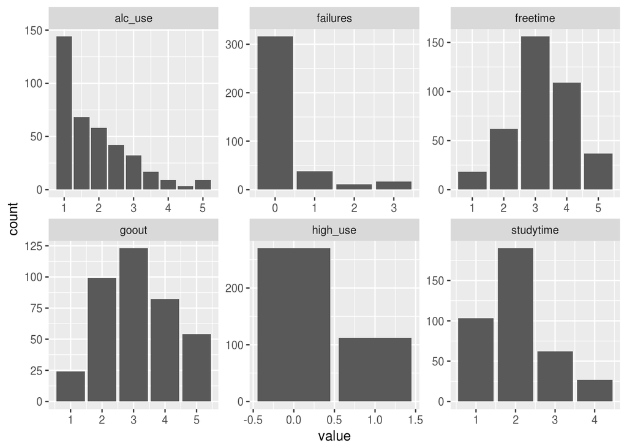

```r
gather(alc_vars) %>% ggplot(aes(value)) + geom_bar() + facet_wrap("key", scales = "free")
```

High alcohol consumption is present in ~100 observations, the vast majority of observations never failed a class, freetime is balanced for ~150 observations, going out is baanced for ~125 observations, ~100 observations study less than 2 hours per week, ~200 observations study 2 to 5 hours per week, ~50 study 5 to 10 hours per week and ~20 study more than 10 hours per week.

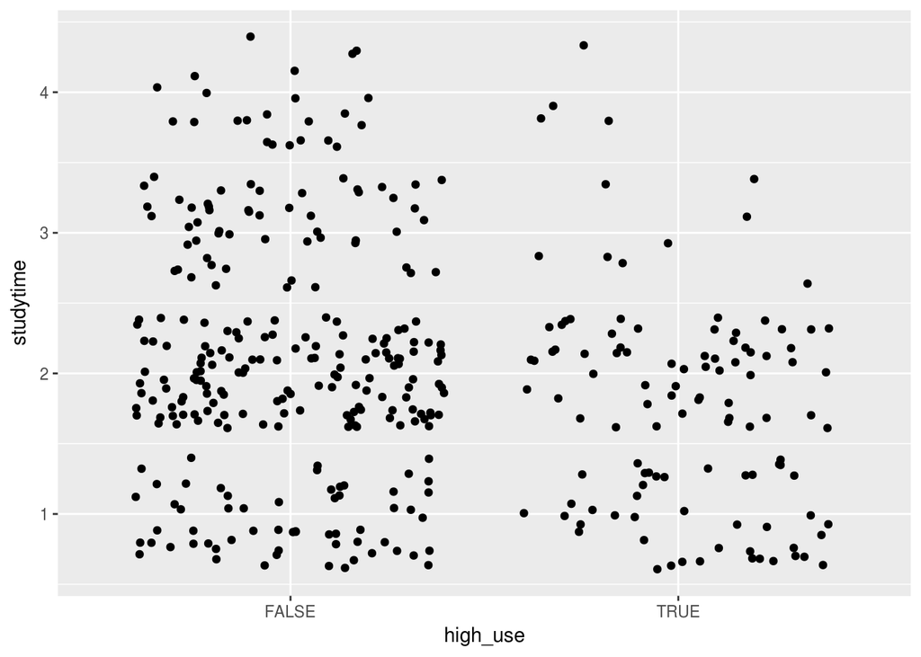

```r
ggplot(data=alc, aes(x = high_use, y = studytime)) + geom_jitter()
```

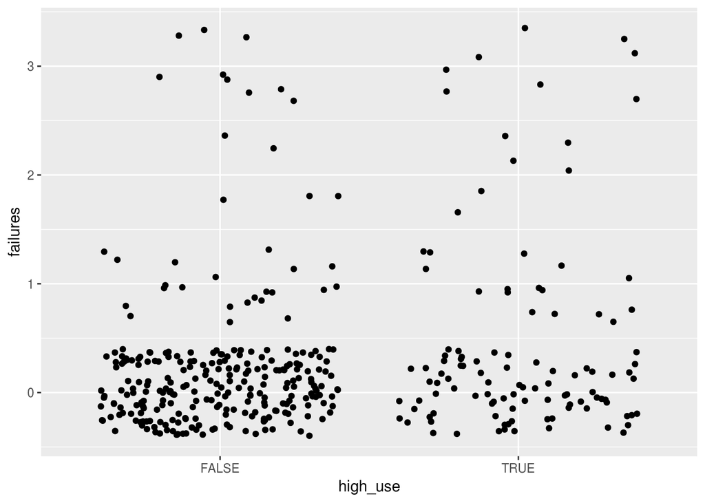

```r
ggplot(data=alc, aes(x = high_use, y = failures)) + geom_jitter()
```

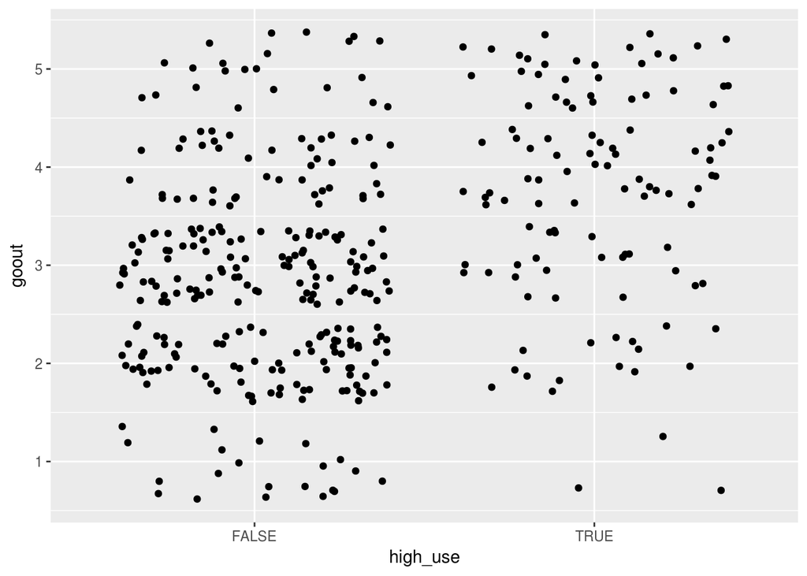

```r
ggplot(data=alc, aes(x = high_use, y = goout)) + geom_jitter()
```

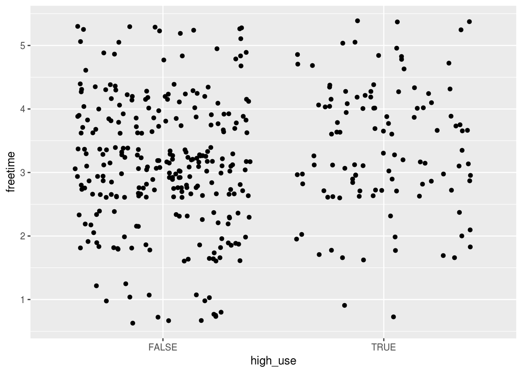

```r
ggplot(data=alc, aes(x = high_use, y = freetime)) + geom_jitter()
```

The plots seem to support my initial hypotheses, except for the variable failures (high number of failures is not associated with high alcohol consumption) and freetime (balanced freetime seems to be correlated with alcohol consumption).

```r
glm(formula = high_use ~ studytime + failures + goout + freetime, data = alc, family = "binomial") %>% summary
```

```
##
## Call:
## glm(formula = high_use ~ studytime + failures + goout + freetime,
##     family = "binomial", data = alc)
##
## Deviance Residuals:
##     Min       1Q   Median       3Q      Max
## -1.8214  -0.7528  -0.5442   0.8552   2.4579
##
## Coefficients:
##             Estimate Std. Error z value Pr(>|z|)
## (Intercept) -2.36957    0.62399  -3.797 0.000146 ***
## studytime   -0.57481    0.16784  -3.425 0.000615 ***
## failures     0.19303    0.16899   1.142 0.253334
## goout        0.70490    0.12039   5.855 4.77e-09 ***
## freetime     0.07209    0.13531   0.533 0.594163
## ---
## Signif. codes:  0 '***' 0.001 '**' 0.01 '*' 0.05 '.' 0.1 ' ' 1
##
## (Dispersion parameter for binomial family taken to be 1)
##
##     Null deviance: 462.21  on 381  degrees of freedom
## Residual deviance: 395.17  on 377  degrees of freedom
## AIC: 405.17
##
## Number of Fisher Scoring iterations: 4
```